# FIRE-RES GEO-Catch

Francesco Pirotti, Erico Kutchartt

27 March, 2023

## Introduction

An app to automatically snap geotagged and oriented photoes from your smartphone upload them to a remote repository for structured storage.

[GO TO APP](https://www.cirgeo.unipd.it/fireres/index.html)

Users must be registered for the image to be accepted. Each image must be associated to a project by selecting the project from the drop down menu. The objective is crowd-sourcing information related to fuel models.

More information in the “description” section.

## Funding

This work is funded from the project [*FIRE-RES, Innovative technologies & socio-ecological-economic solutions for fire resilient territories in Europe*](https://fire-res.eu/) under the European Horizon 2020 research and innovation programme under grant agreement No 101037419

[figure not shown]

## Description

Differences with other crowd-collected data apps:

- it is quite cross-platform, just requires a browser (tesed on Chrome and Firefox) thus works on PCs, smartphones, tablets etc…
- easy to install; installing allows you to load the app also without internet connection - just go to the browser menu and select “install app”
- does not require to install with Google Play or APK files
- *works offline*: images are stored locally if no internet connection is available. As soon as internet connection becomes available, they are synced to the remote storage facility.
- everything is stored in the image file using [EXIF tag](https://exiftool.org/TagNames/EXIF.html) “ImageDescription” thus information is not distributed across multiple files.
  - data is saved as strings separated by pipe character (‘|’), ordere as:
    - ‘project’,
    - ‘longitude’,
    - ‘latitude’,
    - ‘azimuth’,
    - ‘zenith’,
    - ‘timestamp’,
    - ‘accuracy’,
    - ‘uid’.

For example download the image HERE and right click in your PC over the downloaded file and select “properties”. In the image properties go to “details” and you will see the EXIF information below:

FIRELinks|9.2174032|44.3598822|358|86|1679734943295|3|q7p1w0a1nk

## Installation

Users can directly access the app using their browser (Chrome browser is strongly encouraged) via https://www.cirgeo.unipd.it/fireres .

To access the app offline, the user must install the app in their phone.

They can do that directly from their browser by clicking “Install app” banner that pops from the top or bottom of the browser window (see left image below) or, if this banner does not appear, just go to the top right menu and select “install app” (see right image below).

This will add an icon to your smartphone where you can directly open the app also if you are not online.

[figure not shown]

[figure not shown]

## Usage

User can snap photos the APP will double-check that they are GeoTagged correctly and provide alerts in case your camera is not enabled to geotag images.

*The photo will be uploaded to the server if there is internet connection, otherwise it will be cached and synced the next time that the APP is started and internet connection is detected.*

1. tap the photo icon to go to capture mode and start streaming from your camera; you will see two square spaces over a red background:
   - **(A)** top rectangle (or left if smartphone is held horizontally)  
     shows an area with the video stream of your camera. On top are coordinates and accuracy (A) and azimuth and elevation angle.s
   - **(B)** bottom rectangle (or right if smartphone is held horizontally) is striped until the user taps on the video – (see images below);

If user taps the video a screenshot is saved in area (B) also with current coordinates and orientation of when you tap the video – see second image from left below. If user taps the screenshot in image area (B), the image is sent to server (see third image from left below).

[figure not shown]

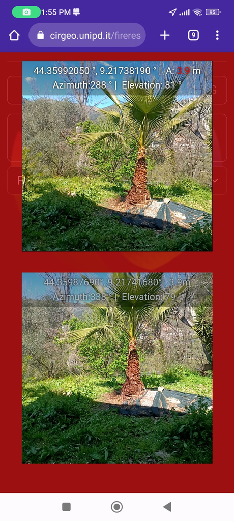

[figure not shown]

**If there is no internet connection, it is not a problem, you can tap the screenshot and your photo will be saved and synced later**

Below are the warning messages that appear if you become offline and when you come back online. All messages are also visible in the log panel.

[figure not shown]

[figure not shown]

2. to **exit** the capture mode tap the red background area or the striped empty screenshot space (B)

## Mapped photoes

An interactive portal is available to check your photoes georeferenced on a map. [OPEN PORTAL HERE](https://www.cirgeo.unipd.it/fireres/incoming/index.html).

**NB: your photoes will be stored and viewed only if you validate your email** by opening the log panel and clicking over your unique user id (UID). This will open your email app and you just have to send the email to the provided address with the automatic subject.

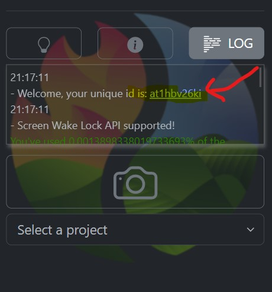

If you do not have an email active in your smartphone or you want to send the validation request on a different email address, you can just send a normal email from anywhere with the following string as subject: **geocatchappid-<yourUID>** where *<yourUID>* is your user id. For example if your app is like the one in the image above, send an email with the following subject:

geocatchappid-at1hbv26ki